# Lab: Multivariate Analysis

Author

Wolfgang Huber, Susan Holmes, TAs of the Stanford class ‘Modern Statistics for Modern Biology’, Julia Ruehle

Published

July 10, 2024

# Goal

In this lab we will learn the basics of multivariate analysis and PCA using a few simple examples.

Work through this lab by running all the R code to your computer and making sure that you understand the input and the output. Make alterations where you seem fit. We encourage you to work through this lab with a partner.

# Setup

The following code installs needed packages

```r
install_if_needed = function(x) {
  p = setdiff(x, installed.packages())
  if (length(p) > 0) BiocManager::install(p)
}
install_if_needed(c("GGally", "factoextra", "ade4"))
```

Obtain data sets that we will be working with.

```r
turtles = read.table(url("https://web.stanford.edu/class/bios221/data/PaintedTurtles.txt"),
                     header = TRUE)
head(turtles)
```

```
  sex length width height
1   f     98    81     38
2   f    103    84     38
3   f    103    86     42
4   f    105    86     40
5   f    109    88     44
6   f    123    92     50
```

```r
download.file(url = "https://web.stanford.edu/class/bios221/data/athletes.RData",
              destfile = "athletes.RData", mode = "wb")
load("athletes.RData")
athletes[1:3, ]
```

```
   m100 long weight highj  m400  m110  disc pole javel  m1500
1 11.25 7.43  15.48  2.27 48.90 15.13 49.28  4.7 61.32 268.95
2 10.87 7.45  14.97  1.97 47.71 14.46 44.36  5.1 61.76 273.02
3 11.18 7.44  14.20  1.97 48.29 14.81 43.66  5.2 64.16 263.20
```

Let’s first get to know our data sets.

**Questions**

1. How many athletes / turtles do you have in the data sets?
2. What’s the record distance in the longjump category? And which athlete (number) made this record?
3. What’s the average time across all athletes for the 100m run?
4. Can you plot the histogram showing the distribution of the times for the 100m run?
5. How many athletes of those who run faster than the average in the 100m run, also run faster than the average in the 1500m distance?

```r
#1
nrow(athletes)
```

```
[1] 33
```

```r
nrow(turtles)
```

```
[1] 48
```

```r
#2
max(athletes$long)
```

```
[1] 7.72
```

```r
which.max(athletes$long)
```

```
[1] 6
```

```r
#3
mean(athletes$m100)
```

```
[1] 11.19636
```

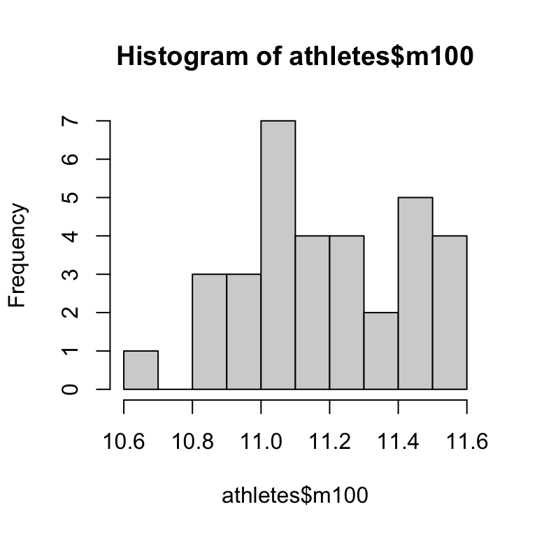

```r
#4
hist(athletes$m100)
```

```r
#5
av100  = mean(athletes$m100)
av1500 = mean(athletes$m1500)

sum( (athletes$m100 > av100) & (athletes$m1500 > av1500) )
```

```
[1] 8
```

```r
#5 alternative solution
with(athletes, table(m100 > mean(m100), m1500 > mean(m1500)))
```

```
        FALSE TRUE
  FALSE    13    5
  TRUE      7    8
```

## Low dimensional data summaries and preparation

It is instructive to first consider 2-dimensional summaries of the data. The function `ggpairs` from the `GGally` package gives a nice summary of the features and how they are correlated with each other.

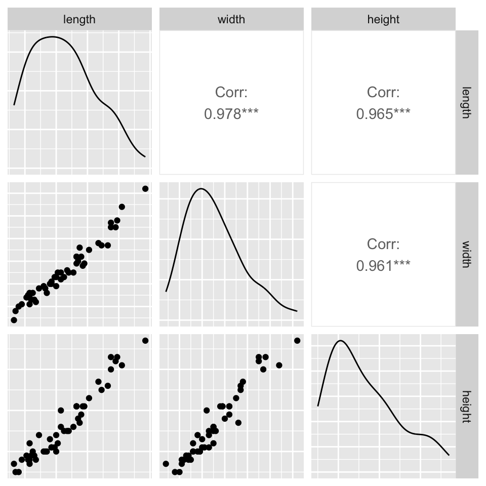

```r
library("GGally")
ggpairs(turtles[, -1], axisLabels = "none")
```

**Questions**

1. What do you see on the diagonal? What do the stars indicate next to the correlation value?
2. Can you repeat this plot for the `athletes` data?
3. In the lecture, we have seen another way to investigate correlations in the data. Use the `pheatmap` function in the package with the same name, `pheatmap`, to illustrate the pairwise correlations of the features in the athletes data set.

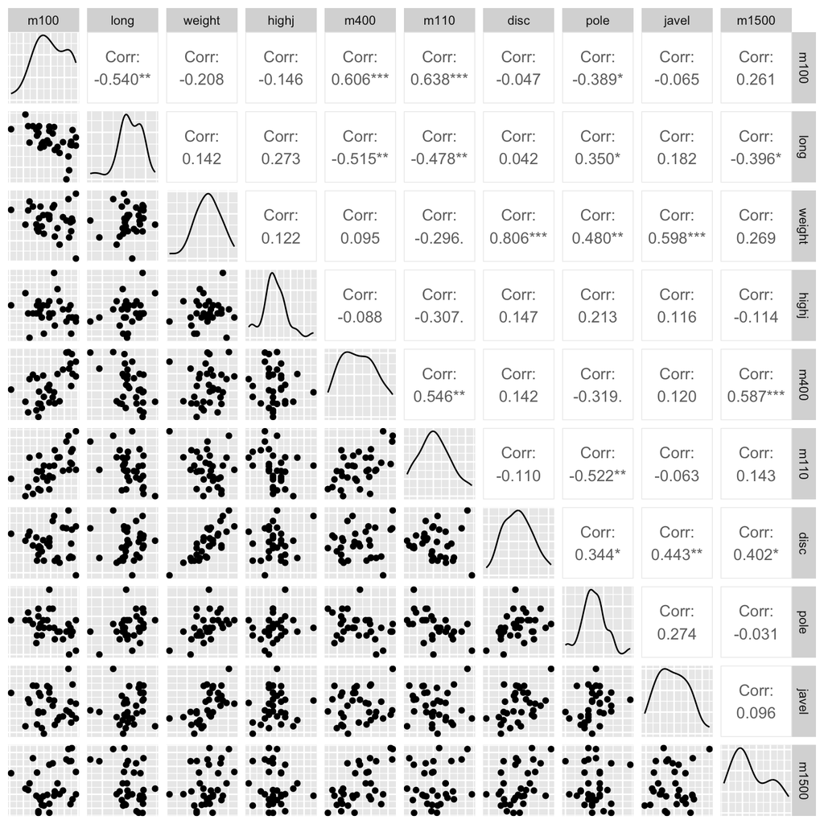

```r
#1
# Diagonal: histogram displaying the distribution of the different variables.
# Stars: significant correlation between the two variables

#2
ggpairs(athletes, axisLabels = "none")
```

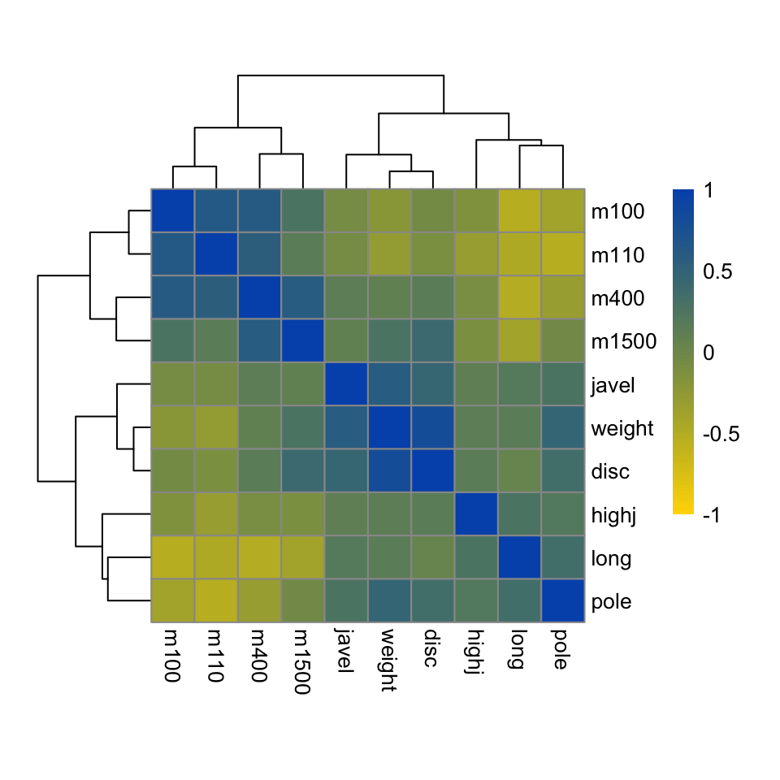

```r
#3
library("pheatmap")
mycolors = colorRampPalette(c("#FFD800", "#0056B9"))(100)
pheatmap(cor(athletes), cellwidth = 20, cellheight = 20,
         color = mycolors, breaks = seq(-1, +1, length.out = length(mycolors) + 1))
```

## Preprocessing the data

In many cases, different variables are measured in different units and at different scales. As discussed in the lecture, we have various options to transform the data. Here, we elect to standardize the data to a common standard deviation. This rescaling is done using the `scale` function, which subtracts the mean and divides by the standard deviation, so that every column has a unit standard deviation and mean zero.

```r
scaledTurtles = data.frame(scale(turtles[, -1]), sex = turtles[, 1])
head(scaledTurtles)
```

```
       length      width     height sex
1 -1.30299868 -1.1389780 -0.9929102   f
2 -1.05887715 -0.9023072 -0.9929102   f
3 -1.05887715 -0.7445267 -0.5163133   f
4 -0.96122853 -0.7445267 -0.7546117   f
5 -0.76593131 -0.5867462 -0.2780148   f
6 -0.08239102 -0.2711852  0.4368805   f
```

**Questions**

1. Can you compute the standard deviation and mean of each column in the `turtles` data frame? Can you do the same on the scaled dataset, i.e. on `scaledturtles`? What was the mean of turtles’ heights before standardizing?

```r
apply(turtles[, -1], 2, sd)
```

```
   length     width    height
20.481602 12.675838  8.392837
```

```r
apply(scaledTurtles[, -4], 2, sd)
```

```
length  width height
     1      1      1
```

```r
apply(turtles[, -1], 2, mean)
```

```
   length     width    height
124.68750  95.43750  46.33333
```

We can visualize two columns/dimensions (for example height and width) of the scaled data using `ggplot`.

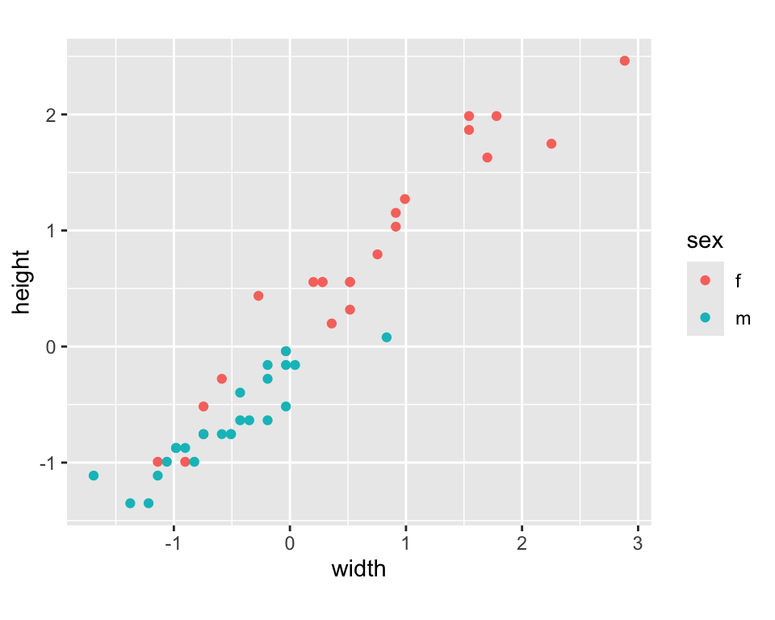

```r
library("ggplot2")
ggplot(scaledTurtles,aes(x = width,y = height, group = sex)) +
  geom_point(aes(color = sex)) + coord_fixed()
```

What is the purpose of the `coord_fixed()` modifier here?